# Casos y Ejemplos de Análisis Multivariante con R

Alex Sánchez y Francesc Carmona

https://github.com/ASPteaching/AMVCasos

# Presentación

Este documento contiene ejemplos de análisis multivariante con R.

Los ejemplos están pensados para ilustrar los capítulos del documento “Notas de Análisis Multivariante” pero se mantienen en un documento aparte para poder ser usados autónomamente.

Algunos de los ejemplos se han inspirado en un documento no publicado del Dr. Carles Cuadras nuestro mentor en Análisis Multivariante por lo que deseamos hacer agradecimiento explícito.

# Análisis de componentes principales

## Ejemplo PCA-1: Búsqueda de factores latentes en datos ecológicos[^1]

Un estudio ecológico recogió datos de 49 gorriones hembras que fueron recogidos casi moribundos después de un temporal. Los investigadores midieron 5 magnitudes de los animales (“length”,“wing”,“head”,“humerus”,“sternum”) y anotaron si los animales sobrevivían o no a los pocos días de ser recogidos (“survival”). Entre otros objetivos, el estudio perseguía encontrar *factores*, es decir algunas variables latentes, no medibles pero presentes en los datos, que explicaran la supervivencia de los mismos ante tempestades como la registrada. Como veremos, las dos primeras componentes principales resultan ser estos factores.

```r
load("datos/gorriones.RData")
colnames(gorriones) <-c("length","wing","head","humerus","sternum","survival")
gorrionesNum<-as.matrix(gorriones[,1:5])
```

Empezamos con una exploración de los datos. Aunque existen muchos paquetes que permiten hacerla nos restringiremos a las funciones de R Base (o de tidyverse) para facilitar la reproducibilidad.

```r
str(gorriones)
```

```
## 'data.frame':    49 obs. of  6 variables:
##  $ length  : num  156 154 153 153 155 163 157 155 164 158 ...
##  $ wing    : num  245 240 240 236 243 247 238 239 248 238 ...
##  $ head    : num  31.6 30.4 31 30.9 31.5 32 30.9 32.8 32.7 31 ...
##  $ humerus : num  18.5 17.9 18.4 17.7 18.6 19 18.4 18.6 19.1 18.8 ...
##  $ sternum : num  20.5 19.6 20.6 20.2 20.3 20.9 20.2 21.2 21.1 22 ...
##  $ survival: Factor w/ 2 levels "N","S": 2 2 2 2 2 2 2 2 2 2 ...
```

```r
summary(gorriones)
```

```
##      length         wing            head          humerus         sternum
##  Min.   :152   Min.   :230.0   Min.   :30.10   Min.   :17.20   Min.   :18.60
##  1st Qu.:155   1st Qu.:238.0   1st Qu.:30.90   1st Qu.:18.10   1st Qu.:20.20
##  Median :158   Median :242.0   Median :31.50   Median :18.50   Median :20.70
##  Mean   :158   Mean   :241.3   Mean   :31.46   Mean   :18.47   Mean   :20.83
##  3rd Qu.:161   3rd Qu.:245.0   3rd Qu.:32.00   3rd Qu.:18.80   3rd Qu.:21.50
##  Max.   :165   Max.   :252.0   Max.   :33.40   Max.   :19.80   Max.   :23.10
##  survival
##  N:28
##  S:21
##
##
##
##
```

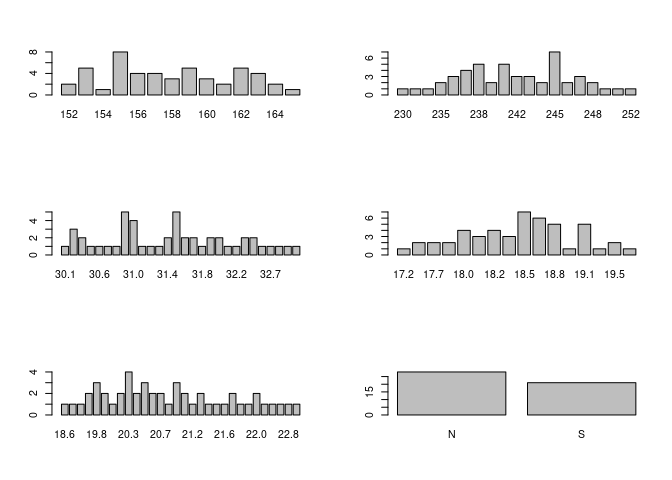

```
##   length     wing     head  humerus  sternum survival
##      0.7      0.7      0.7      0.7      0.7      0.7
```

```r
f<- function(x){
  ifelse (is.numeric(x),
          hist(x, breaks=5),
          barplot(table(x))
  )
}
par(mfrow=c(3,2))
apply(gorriones,2,f)
```

```r
par(mfrow=c(1,1))
```

La escala de las variables numéricas es heterogénea, pero los datos son del mismo tipo (magnitudes biométricas) por lo que nos basaremos en la matriz de covarianzas de los datos *centrados*.

```r
gorrionesNum <- scale(gorrionesNum, center = TRUE, scale=FALSE)
apply(gorrionesNum,2, mean)
```

```
##        length          wing          head       humerus       sternum
## -4.640173e-15 -1.102063e-14  1.232600e-15  4.350306e-16 -2.175331e-16
```

Calculamos la matriz de varianzas ajustando a dividir por n en vez de por (n-1) para que los resultados sean comparables en los dos casos que haremos.

```r
n<- dim(gorriones)[1]
S<-cov(gorrionesNum)*(n-1)/n
show(S)
```

```
##            length      wing      head   humerus   sternum
## length  13.081216 13.333195 1.8828405 1.3034569 2.1474802
## wing    13.333195 25.158684 2.6582257 2.1528530 2.6035818
## head     1.882840  2.658226 0.6187422 0.3352811 0.4061849
## humerus  1.303457  2.152853 0.3352811 0.3119200 0.3324448
## sternum  2.147480  2.603582 0.4061849 0.3324448 0.9627655
```

Calculamos la matriz de correlaciones.

```r
R<-cor(gorrionesNum)
show(R)
```

```
##            length      wing      head   humerus   sternum
## length  1.0000000 0.7349642 0.6618119 0.6452841 0.6051247
## wing    0.7349642 1.0000000 0.6737411 0.7685087 0.5290138
## head    0.6618119 0.6737411 1.0000000 0.7631899 0.5262701
## humerus 0.6452841 0.7685087 0.7631899 1.0000000 0.6066493
## sternum 0.6051247 0.5290138 0.5262701 0.6066493 1.0000000
```

A modo de ilustración empezamos calculando las componentes principales con funciones básicas:

### Mediante diagonalización de la matriz de covarianzas

```r
EIG <- eigen(S)
show(EIG)
```

```
## eigen() decomposition
## $values
## [1] 34.60482313  4.52812344  0.61804191  0.30640029  0.07593901
##
## $vectors
##             [,1]        [,2]        [,3]        [,4]        [,5]
## [1,] -0.53650052  0.82809990  0.15649065  0.04020969 -0.01765243
## [2,] -0.82901535 -0.55051223  0.05774395  0.06902156  0.03964203
## [3,] -0.09649615  0.03356237 -0.23751487 -0.89762653  0.35695288
## [4,] -0.07435219 -0.01459529 -0.20324541 -0.30724056 -0.92658150
## [5,] -0.10030441  0.09923405 -0.93512262  0.30575979  0.11021920
```

Los vectores propios, es decir las columnas de la matriz “eigen$vectors” son las coordenadas de las cinco componentes principales.

La transformación de los datos asociada a las componentes principales se obtiene multiplicando la matriz original por la matriz de vectores propios

```r
eigenVecs1 <- EIG$vectors
PCAS1 <- gorrionesNum %*% eigenVecs1
head(PCAS1)
```

```
##            [,1]      [,2]        [,3]        [,4]        [,5]
## [1,] -1.9664223 -3.689713  0.16801141 -0.06169590  0.16647852
## [2,]  3.5023362 -2.714180  0.81488580  0.49908927  0.03198139
## [3,]  3.8434585 -3.430206 -0.52085909  0.07244318 -0.08926600
## [4,]  7.2613378 -1.260991 -0.21176257 -0.02111595  0.32098994
## [5,]  0.2503842 -3.441451  0.08648433 -0.24206207 -0.04555039
## [6,] -7.4958530  1.051783  0.80825616 -0.03255193 -0.15422636
```

Con esto podemos hacer una primera representación.

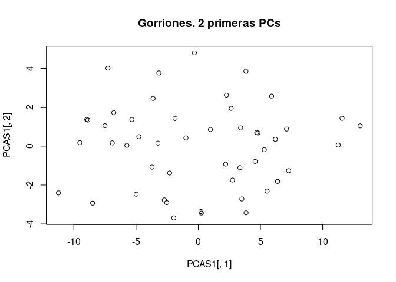

```r
plot(PCAS1[,1], PCAS1[,2], main = "Gorriones. 2 primeras PCs")
```

Los valores propios representan la varianza de las componentes por lo que cada valor dividido por la suma de éstos es el porcentaje de variabilidad explicado.

```r
vars1<- EIG$values/sum(EIG$values)
round(vars1,3)
```

```
## [1] 0.862 0.113 0.015 0.008 0.002
```

Podemos usar estos porcentajes para etiquetar los ejes indicando la importancia de cada componente.

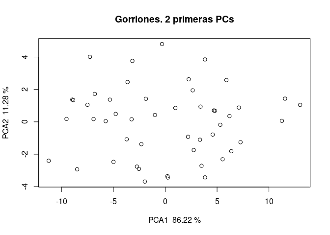

```r
xlabel <- paste("PCA1 ", round(vars1[1]*100, 2),"%" )
ylabel <- paste("PCA2 ", round(vars1[2]*100,2),"%" )
plot(PCAS1[,1], PCAS1[,2], main = "Gorriones. 2 primeras PCs",
     xlab=xlabel, ylab=ylabel)
```

Finalmente podemos visualizar si el gorrión ha sobrevivido o no representándolo en el gráfico con colores distintos.

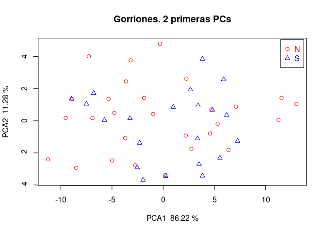

```r
bgSurv<- colSurv <- ifelse(gorriones$survival=="N", "red", "blue")
pchSurv <- ifelse(gorriones$survival=="N",1,2)
plot(PCAS1[,1], PCAS1[,2], main = "Gorriones. 2 primeras PCs",
     xlab=xlabel, ylab=ylabel,
     pch=pchSurv, col=colSurv, bg=bgSurv)
legend( "topright"  , inset = c(0.01,0.01), cex =1,
        bty = "y", legend = c("N", "S"),
        text.col = c("red", "blue"),
        col = c("red", "blue"),
        pt.bg = c("red","blue"),
        pch = c(1,2)
        )
```

### Calculo de las componentes principales mediante las funcionesn `princomp` y `prcomp`

La función `princomp` calcula las componentes principales recurriendo básicamente al mismo método, a diferencia de la función `prcomp` que calcula las componentes principales mediante la descomposición en valores singulares de la matriz de datos.

```r
PCAS2 <- princomp(gorrionesNum)
names(PCAS2)
```

```
## [1] "sdev"     "loadings" "center"   "scale"    "n.obs"    "scores"   "call"
```

```r
PCAS3 <- prcomp(gorrionesNum)
names(PCAS3)
```

```
## [1] "sdev"     "rotation" "center"   "scale"    "x"
```

Observemos como algunos resultados coinciden mientras que otros tendremos que ajustarlos.

EL argumento `sdev` contiene las desviaciones estándard es decir las raíces cuadradas de los valores propios.

```r
PCAS2$sdev
```

```
##    Comp.1    Comp.2    Comp.3    Comp.4    Comp.5
## 5.8825864 2.1279388 0.7861564 0.5535344 0.2755703
```

```r
PCAS3$sdev
```

```
## [1] 5.9435475 2.1499905 0.7943033 0.5592706 0.2784261
```

```r
sqrt(EIG$values)
```

```
## [1] 5.8825864 2.1279388 0.7861564 0.5535344 0.2755703
```

Hay una ligera diferencia en los resultados calculados por `prcomp` que podemos atribuir a la forma de cálculo.

El argumento `loadings` contiene los vectores propios en el objeto calculado por `princomp.

En el caso de `prcomp` estan en el objeto `rotation`.

```r
PCAS2$loadings
```

```
##
## Loadings:
##         Comp.1 Comp.2 Comp.3 Comp.4 Comp.5
## length   0.537  0.828  0.156
## wing     0.829 -0.551
## head                  -0.238 -0.898 -0.357
## humerus               -0.203 -0.307  0.927
## sternum  0.100        -0.935  0.306 -0.110
##
##                Comp.1 Comp.2 Comp.3 Comp.4 Comp.5
## SS loadings       1.0    1.0    1.0    1.0    1.0
## Proportion Var    0.2    0.2    0.2    0.2    0.2
## Cumulative Var    0.2    0.4    0.6    0.8    1.0
```

```r
PCAS3$rotation[,1]
```

```
##     length       wing       head    humerus    sternum
## 0.53650052 0.82901535 0.09649615 0.07435219 0.10030441
```

```r
EIG$vectors
```

```
##             [,1]        [,2]        [,3]        [,4]        [,5]
## [1,] -0.53650052  0.82809990  0.15649065  0.04020969 -0.01765243
## [2,] -0.82901535 -0.55051223  0.05774395  0.06902156  0.03964203
## [3,] -0.09649615  0.03356237 -0.23751487 -0.89762653  0.35695288
## [4,] -0.07435219 -0.01459529 -0.20324541 -0.30724056 -0.92658150
## [5,] -0.10030441  0.09923405 -0.93512262  0.30575979  0.11021920
```

Observamos como en este caso coinciden todos los valores, salvo por el signo del primer valor propio del cálculo basado en la diagonalización. Esto no es un error sino que se debe a que el vector propio no es único y está indeterminado por un producto por -1.

Finalmente el argumento `scores` contiene las componentes principales calculadas por `princomp`. en el caso de `prcomp` se encuentran en el campo `x`. Para hacerlas comparables centraremos las componentes que hemos calculado nosotros.

```r
head(PCAS2$scores)
```

```
##          Comp.1    Comp.2      Comp.3      Comp.4      Comp.5
## [1,]  1.9664223 -3.689713  0.16801141 -0.06169590 -0.16647852
## [2,] -3.5023362 -2.714180  0.81488580  0.49908927 -0.03198139
## [3,] -3.8434585 -3.430206 -0.52085909  0.07244318  0.08926600
## [4,] -7.2613378 -1.260991 -0.21176257 -0.02111595 -0.32098994
## [5,] -0.2503842 -3.441451  0.08648433 -0.24206207  0.04555039
## [6,]  7.4958530  1.051783  0.80825616 -0.03255193  0.15422636
```

```r
head(PCAS3$x)
```

```
##             PC1       PC2         PC3         PC4         PC5
## [1,]  1.9664223  3.689713 -0.16801141  0.06169590  0.16647852
## [2,] -3.5023362  2.714180 -0.81488580 -0.49908927  0.03198139
## [3,] -3.8434585  3.430206  0.52085909 -0.07244318 -0.08926600
## [4,] -7.2613378  1.260991  0.21176257  0.02111595  0.32098994
## [5,] -0.2503842  3.441451 -0.08648433  0.24206207 -0.04555039
## [6,]  7.4958530 -1.051783 -0.80825616  0.03255193 -0.15422636
```

```r
head(PCAS1)
```

```
##            [,1]      [,2]        [,3]        [,4]        [,5]
## [1,] -1.9664223 -3.689713  0.16801141 -0.06169590  0.16647852
## [2,]  3.5023362 -2.714180  0.81488580  0.49908927  0.03198139
## [3,]  3.8434585 -3.430206 -0.52085909  0.07244318 -0.08926600
## [4,]  7.2613378 -1.260991 -0.21176257 -0.02111595  0.32098994
## [5,]  0.2503842 -3.441451  0.08648433 -0.24206207 -0.04555039
## [6,] -7.4958530  1.051783  0.80825616 -0.03255193 -0.15422636
```

De nuevo los valores coinciden aunque los dos métodos `prcomp` y `princomp` han centrado las componentes principales antes de almacenarlas.

### Interpretación de las componentes

A partir de los resultados obtenidos podemos escribir así las dos primeras componentes:

$Y_1 = 0.5365\times length + 0.8290\times wing + 0.0965\times head + 0.0743\times humerus + 0.1003\times sternum$

$Y_2 = -0.8281\times length + 0.5505\times wing -0.0336\times head + 0.0146\times humerus -0.0992\times sternum$

La primera componente tiene todos los coeficientes positivos del mismo signo y se puede interpretar como el **tamaño** del gorrión.

La segunda componente tiene coeficientes positivos y negativos y se puede interpretar como un factor **forma**. En este caso por contraposición de las dos primeras variables. En el eje PC2 las variables con mayor peso en valor absoluto son las mismas pero aquí una aparece con signo positivo y la otra con signo negativo: 0.55 para las alas, −0.83 para la longitud. Esta segunda componente explica un 11.2% de la variabilidad.

Valores positivos de PC2 corresponderán a pájaros cortos con gran envergadura de alas, y valores negativos de PC2 corresponderán a pájaros más proporcionados o incluso de mayor longitud que envergadura.

Tamaño y forma son pues dos componentes interrelacionadas que, entre ambas explican el 97.51% de la variabilidad. Si atendemos a la distribución de los “S” y “N” en el gráfico podríamos sugerir que los gorriones “extremos” ya sea en tamaño o en forma tienen menos posibilidades de sobrevivir.

## Ejemplo PCA-2: Detección del efecto batch en datos de microarrays.

Si la presencia del efecto batch se conoce o espera puede, en principio, ser controlado o cancelado mediante un adecuado diseño experimental, en el que el lote se tratará usualmente como un bloque. En este caso un adecuado balanceo entre bloques y tratamientos puede cancelar el efecto batch. Alternativamente, dicho efecto puede incluirse como un factor en el modelo de análisis de la varianza, lo que eliminara del análisis la variación atribuible al lote.

En muchas (demasiadas) ocasiones el efecto batch no ha sido considerado de antemano, o incluso, cuando sí lo ha sido, puede que no se hayan tenido en cuenta todos los posible efectos (a lo mejor se ha tenido en cuenta el día pero no que los reactivos utilizados provenían de dos lotes o que las piezas se han procesado en grupos, o …).

En prevención de los problemas que esto puede generar es conveniente realizar algún tipo de análisis exploratorio que permita detectar la posible presencia de estos efectos. En caso de detectarse efectos indeseados puede plantearse su eliminación mediante alguna de las técnicas disponibles para ello.

### Los datos para el análisis

Los datos para este ejemplo consisten en datos de microarrays de expresión génica, tipo hgu95-a utilizados para analizar un estudio de cáncer de mama en el que se analiza el efecto de distintos tratamientos y distintos tiempos de exposición a éstos, sobre la expresión de los genes.

Los datos y la información del estudio se hallan disponibles en la base de datos Gene Expression Omnibus (GEO, http://www.ncbi.nlm.nih.gov/geo con número de acceso ``GSE848’’.

```r
load(file.path("datos", "datosMicroarrays.Rda"))
head(x)
```

```
##             E2.8.A   E2.8.B  E2.48.A  E2.48.B E2.ICI.8.A E2.ICI.8.B E2.ICI.48.A
## X100_g_at 7.933691 8.098032 8.256445 7.619120   7.800253   7.886916    8.015694
## X101_at   6.877744 6.811214 6.803485 6.989820   6.816344   7.043301    6.716991
## X102_at   4.491853 3.121015 4.655352 3.877744   3.536053   2.765535    4.343408
## X103_at   5.244126 3.350497 3.017922 4.277985   3.419539   2.536053    3.916477
## X104_at   5.173927 4.842979 5.350497 4.596935   4.209453   4.990955    5.185867
## X105_at   2.104337 1.807355 2.263034 2.536053   3.485427   1.584963    4.035624
##           E2.ICI.48.B E2.Ral.8.A E2.Ral.8.B E2.Ral.48.A E2.Ral.48.B E2.TOT.8.A
## X100_g_at    7.878971   7.660353   7.613237    7.798958    7.675957   8.126188
## X101_at      6.772150   6.515700   6.774787    6.205549    6.841722   6.623516
## X102_at      3.017922   3.350497   2.963474    4.153805    3.169925   4.321928
## X103_at      3.954196   3.201634   2.459432    4.566815    2.765535   2.722466
## X104_at      4.781360   5.314697   4.921246    5.228819    4.807355   4.672425
## X105_at      4.321928   2.807355   3.722466    4.153805    3.459432   4.232661
##           E2.TOT.8.B E2.TOT.48.A E2.TOT.48.B
## X100_g_at   8.037821    8.249351    7.720415
## X101_at     6.888743    6.675251    7.130313
## X102_at     1.536053    4.035624    3.857981
## X103_at     2.510962    3.104337    3.104337
## X104_at     5.255501    5.057450    5.185867
## X105_at     2.321928    3.765535    2.201634
```

```r
rownames(targets) <- targets$ShortName
```

La tabla `targets`contiene información sobre el tratamiento y el lote de cada muestra analizada. los individuos analizados.

```r
kableExtra::kable(targets)
```

|  | Filename | Treatment | Time | Batch | ShortName |
| --- | --- | --- | --- | --- | --- |
| E2.8.A | GSM13099.txt | E2 | 8 | A | E2.8.A |
| E2.8.B | GSM13138.txt | E2 | 8 | B | E2.8.B |
| E2.48.A | GSM13139.txt | E2 | 48 | A | E2.48.A |
| E2.48.B | GSM13140.txt | E2 | 48 | B | E2.48.B |
| E2.ICI.8.A | GSM15900.txt | E2.ICI | 8 | A | E2.ICI.8.A |
| E2.ICI.8.B | GSM15901.txt | E2.ICI | 8 | B | E2.ICI.8.B |
| E2.ICI.48.A | GSM15902.txt | E2.ICI | 48 | A | E2.ICI.48.A |
| E2.ICI.48.B | GSM15903.txt | E2.ICI | 48 | B | E2.ICI.48.B |
| E2.Ral.8.A | GSM15904.txt | E2.Ral | 8 | A | E2.Ral.8.A |
| E2.Ral.8.B | GSM15905.txt | E2.Ral | 8 | B | E2.Ral.8.B |
| E2.Ral.48.A | GSM15906.txt | E2.Ral | 48 | A | E2.Ral.48.A |
| E2.Ral.48.B | GSM15907.txt | E2.Ral | 48 | B | E2.Ral.48.B |
| E2.TOT.8.A | GSM15908.txt | E2.TOT | 8 | A | E2.TOT.8.A |
| E2.TOT.8.B | GSM15909.txt | E2.TOT | 8 | B | E2.TOT.8.B |
| E2.TOT.48.A | GSM15910.txt | E2.TOT | 48 | A | E2.TOT.48.A |
| E2.TOT.48.B | GSM15911.txt | E2.TOT | 48 | B | E2.TOT.48.B |

Obsérvese que los nombres de las columnas de los datos coinciden con los de las filas de `targets`

```r
rownames(targets)==colnames(x)
```

```
##  [1] TRUE TRUE TRUE TRUE TRUE TRUE TRUE TRUE TRUE TRUE TRUE TRUE TRUE TRUE TRUE
## [16] TRUE
```

### Análisis del efecto batch

La detección de efectos batch puede hacerse de diversas formas pero esencialmente, de lo que se trata es de ver si las muestras se agrupan por causas distintas a las que se podría esperar, por ejemplo si en vez de parecerse más entre si muestras que han recibido un mismo tratamiento, lo hacen las que han recibido algún tratamiento el mismo día.

La detección de estos efectos puede hacerse mediante distintas técnicas de las que, la más popular es el análisis de componentes principales. Una vez detectado si existe efecto batch es posible mirar de eliminarlo. Si cada tratamiento en estudio está presente en cada lote suele ser posible separar ambos efectos. Si, no es así no suele ser posible evitar cierto grado de tratamiento–lote.

En este ejercicio nos centraremos únicamente en la detección del efecto, no en su eliminación.

Cabe destacar una diferencia entre esta aplicación del PCA y la anterior.

- En el caso de los gorriones hemos utilizado el PCA para buscar y explicar variables latentes que nos ayuden a interpretar los datos.
- En este caso no pretendemos detectar variables asociadas al efecto batch, es decir no buscaremos interpretarlos sino tan sólo ponerlo en evidencia.

Esto no es porque no sea importante saber que causa, sino porque muchas veces puede tener orígenes desconocidos y sobretodo es plausible que no hayamos recogido información de las variables que lo explican. Esto ha llevado al desarrollo de métodos multivariantes, como el análisis de variables subrogadas del paquete SVA https://www.ncbi.nlm.nih.gov/pmc/articles/PMC3307112/ orientadas a modelizar y quitar el efecto batch globalmente sin buscar su interpretación.

### Detectando el efecto batch

La detección de efectos batch puede hacerse de diversas formas pero esencialmente, de lo que se trata es de ver *si las muestras se agrupan por causas distintas a las que se podría esperar*, por ejemplo si en vez de parecerse más entre si muestras que han recibido un mismo tratamiento, lo hacen las que han recibido cualquier tratamiento el mismo día.

La detección de estos efectos puede hacerse mediante distintas técnicas de las que, la más popular es el análisis de componentes principales.

Una vez detectado si existe efecto batch es posible mirar de eliminarlo. Si cada tratamiento en estudio está presente en cada lote suele ser posible separar ambos efectos usando el análisis de la varianza. Si, no es así no suele ser posible evitar cierto grado de tratamiento-lote.

```r
colores <- c(rep("black", 4), rep("blue", 4), rep("red", 4), rep("green", 4))
```

Un diagrama de cajas de todos los datos no muestra ninguna tendencia clara que separe los lotes A y B

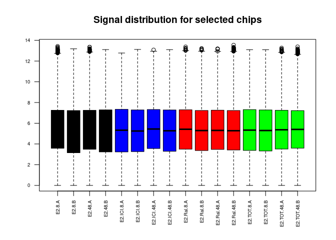

```r
sampleNames <- targets$ShortName
boxplot(as.data.frame(x), cex.axis=0.6, col=colores, las=2, names=sampleNames,
        main="Signal distribution for selected chips")
```

Para simplificar la visualización, la función siguiente combina la realización de un PCA, la extracción de las dos primeras componentes y su visualización, debidamente etiquetada, por tratamientos y por lotes.

```r
plotPCA <- function ( X, labels=NULL, colors=NULL, dataDesc="", scale=FALSE, cex4text=0.8)
{
  pcX<-prcomp(X, scale=scale) # o prcomp(t(X))
  loads<- round(pcX$sdev^2/sum(pcX$sdev^2)*100,1)
  xlab<-c(paste("PC1",loads[1],"%"))
  ylab<-c(paste("PC2",loads[2],"%"))
  if (is.null(colors)) colors=1
  plot(pcX$x[,1:2],xlab=xlab,ylab=ylab, col=colors,
       xlim=c(min(pcX$x[,1])-10, max(pcX$x[,1])+10),
       ylim=c(min(pcX$x[,2])-10, max(pcX$x[,2])+10))
  text(pcX$x[,1],pcX$x[,2], labels, pos=3, cex=cex4text)
  title(paste("Plot of first 2 PCs for expressions in", dataDesc, sep=" "), cex=0.8)
}
```

Con esta función podemos realizar y visualizar de forma sencilla el PCA de los datos. Obsérvese que realizamos el PCA de los datos traspuestos puesto que los datos de microarrays se presentan traspuestos a la forma habitual, es decir las filas son las variables y las columnas los individuos.

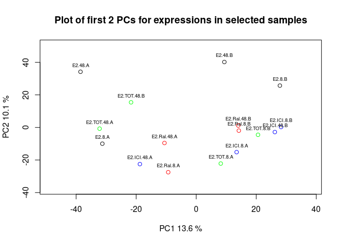

```r
sampleNames <- targets$ShortName
plotPCA(t(x), labels=sampleNames, colors=colores, dataDesc="selected samples", cex4text=0.6)
```

Esto sugiere que el efcto “Batch” puede enmascarar los efectos de los tratamientos por lo qyue será recomendable eliminarlo para poder estudiar bien el efecto Tratamiento.

En este caso esto será posible, al menos en parte, porque el diseño se encuentra balanceado entre Tratamiento, Tiempo y Batch, por lo que un modelo de Análisis de la Varianza nos permitirá descomponer la variabilidad asociada a cada causa y eliminar la debida al efecto batch.

### Análisis basado en distancias

Un enfoque alternativo aunque relacionado es realizar un análisis basado en distancias. Podemos hacerlo calculando la matriz de distancias y visualizándola mediante un mapa de colores o usando escalamiento multidimensional que se discute más adelante.

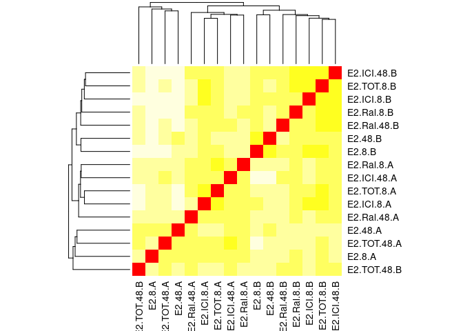

```r
manDist <- dist(t(x))
heatmap (as.matrix(manDist), col=heat.colors(16))
```

```r
require(MASS)
```

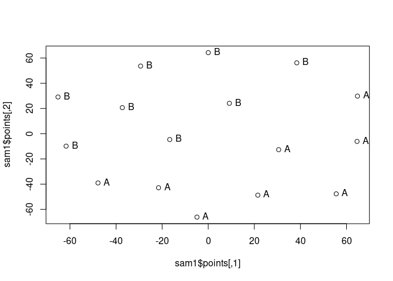

```r
sam1<-sammon (manDist, trace=FALSE)
plot(sam1$points)
text(sam1$points, targets$Batch, pos=4)
```

Todas las visualizaciones coinciden en mostrar una separación asociada al factor batch A o B.

# Análisis de proximidades

## Breve repaso sobre medidas de similaridad

Supongamos que tenemos $n$ variables *dicotómicas*, basadas en ausencia (-) o presencia (+) de caracteres cualitativos. Un individuo queda entonces caracterizado por la presencia o la ausencias de los caracteres, y dos individuos seran tano más similares cuanto más parecido sea su perfil de presencias-ausencias.

|  | $x_1$ | $x_2$ | $x_3$ | $\cdots$ | $x_n$ |
| --- | --- | --- | --- | --- | --- |
| $i$ | $+$ | $-$ | $+$ | $\cdots$ | $+$ |

Podemos determinar a asociación entre dos individuos $i$, $j$ a partir de la tabla de frecuencias

|  |  |  | $i$ |  |
| --- | --- | --- | --- | --- |
|  |  | $+$ |  | $-$ |
|  | $+$ | $a$ |  | $b$ |
| $j$ |  |  |  |  |
|  | $-$ | $c$ |  | $d$ |

donde: $n = a + b + c + d$, que contiene:

- el número de caracteres *comunes* a $i$ y a $j$, $a$,
- el número de caracteres *presentes en $i$ pero no en $j$*, $b$,
- el número de caracteres *presentes en $j$ pero no en $i$*, $c$,
- el número de caracteres *no comunes* a $i$ y a $j$, $d$,

La asociación se mide mediante un *coeficiente de similaridad* $s_{ij}$ que verifica, en general:

- $0 \leq s_{ij} \leq 1$,
- $s_{ij} = 0$ si $c+b = n$ **(discrepancia total)**
- $s_{ij} = 1$ si $a+d = n$ **(concordancia total)**

## Ejemplo 1: Distancias geográficas[^2]

En muchas ocasiones se dispone de datos en forma de una matriz de *distancias*, de *similaridades* o de *disimilariddes*. En algún sentido, que puede variar de un caso a otro, estas matrices cuantifican el parecido, o la diferencia, o incluso la distancia geográfica por parejas de un grupo de variables. Nuestro objetivo, en estos casos, suele ser intentar recuperar, a partrir de las maytrices anteriores, las coordenadas de los puntos, de forma que podamos visualizarlos mostrando las relaciones entre ellos.

Este ejemplo utiliza las distancias *aéreas*, en millas, entre 10 ciudades de Estados Unidos. A partir de éstas deseamos recuperar las coordenadas de cada dciudad de forma que podamos representarlas en un plano que refleje lo mejor posible las distancias entre ellas. Hemos de tener en cuenta que puesto que se trata de duistancias aéreas, no son distancias euclídeas (los aviones no se desplazan en línea recta) por lo que la recuperación tan ssólo será aproximada.

```r
library(readxl)
DistSim <- as.data.frame(read_excel("datos/Dist_Sim_Disim.xlsx", sheet = "GeoDistances"))
rownames(DistSim) <- DistSim[,1]
DistSim <-as.matrix(DistSim [,-1])
```

```r
library(magrittr)
DistSim %>%
  kableExtra::kbl() %>%
  kableExtra::kable_paper("hover", full_width = F, font_size = 9)
```

|  | Atl | Chi | Den | Hou | LA | Mia | NY | SF | Sea | Was |
| --- | --- | --- | --- | --- | --- | --- | --- | --- | --- | --- |
| Atlanta | 0 | NA | NA | NA | NA | NA | NA | NA | NA | NA |
| Chicago | 587 | 0 | NA | NA | NA | NA | NA | NA | NA | NA |
| Denver | 1212 | 920 | 0 | NA | NA | NA | NA | NA | NA | NA |
| Houston | 701 | 940 | 879 | 0 | NA | NA | NA | NA | NA | NA |
| Los Angeles | 1936 | 1745 | 831 | 1734 | 0 | NA | NA | NA | NA | NA |
| Miami | 604 | 1188 | 1726 | 968 | 2339 | 0 | NA | NA | NA | NA |
| New York | 748 | 713 | 1631 | 1420 | 2451 | 1092 | 0 | NA | NA | NA |
| San Francisco | 2139 | 1858 | 949 | 1645 | 347 | 2594 | 2571 | 0 | NA | NA |
| Seattle | 2182 | 1737 | 1021 | 1891 | 959 | 2734 | 2408 | 678 | 0 | NA |
| Washington | 543 | 597 | 1494 | 1220 | 2300 | 923 | 205 | 2442 | 2329 | 0 |

Nuestro objetivo es lograr una visualización de los datos que represente lo mejor posible las distancias entre éstas, aunque no conozcamos, como en este caso, las coordenadas de cada ciudad. Además, puesto que se trata de distancias aéreas, no será posible recuperar directamente las distancias euclídeas entre las ciudades, por lo que procederemos a realizar un escalamiento multidimensional clásico

Siguiendo a Everitt and Hothorn (2011), capítulo 4, procederemos a:

- Diagonalizar la matriz de distancias.
- Obtener las coordenadas de cada individuo (ciudad).

$$X = V_1\cdot \Lambda_1^{\frac 12} ,$$
donde $V_1$ contiene los vectores propios no nulos de $B$ y
$$\Lambda_1^{\frac 12}= \mbox{diag}(\lambda_1^{\frac 12}, \lambda_2^{\frac 12},..., \lambda_q^{\frac 12}),$$
contiene la raíz cuadrada de los primeros $q$ valores propios no nulos de $B$.

Para realizar un multidimensonal scaling clásico nos basaremos en la instrucción `cmdscale` del paquete `stats`:

```r
airdist <- as.dist(as.matrix(DistSim))
airline_mds <- cmdscale(airdist, k = 9, eig = TRUE)
airline_mds$points
```

```
##                     [,1]       [,2]        [,3]        [,4]         [,5]
## Atlanta        -712.4178  157.34246   67.519636  33.9648977  -8.45853360
## Chicago        -374.1124 -332.99012    2.928936  28.7749927 -15.84330898
## Denver          486.6607   14.78013  -41.304984  45.9929928  14.75126177
## Houston        -228.9426  515.95616 -465.504161  -0.5668829   0.04794259
## Los Angeles    1219.0246  277.99731  458.396262  -0.1879388   0.02297080
## Miami         -1128.4262  598.95103  142.601024 -32.8128340   1.93168561
## New York      -1062.3316 -534.19580   39.122338 -35.6808373   0.22573428
## San Francisco  1423.4269  181.43505 -110.535264 -24.0833935  -4.86588885
## Seattle        1347.8203 -536.47617 -140.929698 -18.5126346   0.87459912
## Washington     -970.7018 -342.80004   47.705911   3.1116379  11.31353725
```

Si inspeccionamos los valores propios veremos que algunos son negativos:

```r
lam <- airline_mds$eig
show(lam)
```

```
##  [1]  9.609694e+06  1.561695e+06  4.893155e+05  7.379541e+03  6.963801e+02
##  [6] -7.566996e-10 -4.056578e+02 -9.605809e+02 -2.371259e+04 -2.945694e+05
```

Esto se explica porque, tal como se ha comentado, las distancias no son euclídeas. Para determinar si podemos prescindir de algunas componentes calculamos, como hacíamos en el análisis de componentes principales, el porcentaje de la suma de los valores propios (en valor absoluto o al cuadrado) que representa cada valor propio individual.

```r
cumsum(abs(lam)) / sum(abs(lam))
```

```
##  [1] 0.8015807 0.9318476 0.9726633 0.9732788 0.9733369 0.9733369 0.9733708
##  [8] 0.9734509 0.9754289 1.0000000
```

```r
cumsum(lam^2) / sum(lam^2)
```

```
##  [1] 0.9709215 0.9965638 0.9990812 0.9990818 0.9990818 0.9990818 0.9990818
##  [8] 0.9990818 0.9990877 1.0000000
```

El elevado valor del primer término en ambos casos, muestra como, bastará con las dos primeras coordenadas para obtener una buena representación.

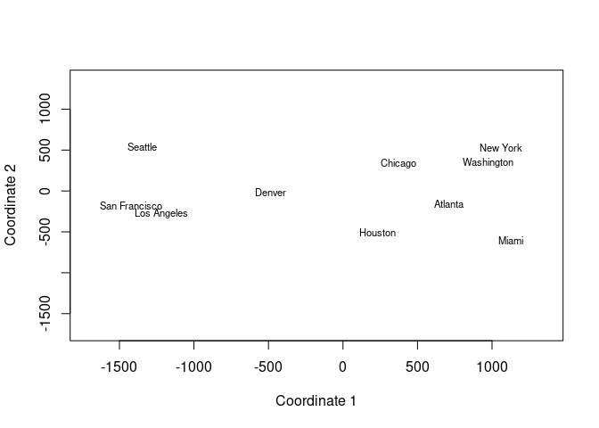

```r
lim <- range(airline_mds$points[,1] * (-1)) * 1.2
plot(airline_mds$points[,1] * (-1), airline_mds$points[,2] * (-1),
     type = "n", xlab = "Coordinate 1", ylab = "Coordinate 2",
     xlim = lim, ylim = lim)
text(airline_mds$points[,1] *(-1), airline_mds$points[,2] * (-1),
     labels(airdist), cex = 0.7)
```

Como puede verse en el gráfico la primera coordenada representa la dirección Este Oeste, y la seguna la Norte-Sur. Las posiciones de los puntos reproducen relativamente bien las posiciones relativas de las ciudades en el mapa.

## Ejemplo 2: Similaridades entre partidos políticos[^3]

La tabla siguiente contiene una matriz de distancias entre partidos políticos españoles en la primera década del siglo XXI obtenida a partir de 11 características sociológicas y económicas (sobre constitución del estado, poder judicial y ejecutivo, financiación autonómica, etc.) aplicando la similaridad de Jaccard. Las distancias estan elevadas al cuadrado.

```r
require(readxl)
simPartidos <- as.data.frame(read_excel("datos/Dist_Sim_Disim.xlsx", sheet = "SimilarJaccard-Partidos"))
rownames(simPartidos) <- simPartidos[,1]
simPartidos <-as.matrix(simPartidos [,-1])
```

```r
library(magrittr)
simPartidos %>%
  kableExtra::kbl() %>%
  kableExtra::kable_paper("hover", full_width = F, font_size = 9)
```

|  | PP | PSOE | CU | IU | ERC | ICV |
| --- | --- | --- | --- | --- | --- | --- |
| PP | 0.000 | NA | NA | NA | NA | NA |
| PSOE | 1.400 | 0.000 | NA | NA | NA | NA |
| CU | 1.714 | 2.000 | 0.000 | NA | NA | NA |
| IU | 1.273 | 0.444 | 1.800 | 0.000 | NA | NA |
| ERC | 2.000 | 1.250 | 1.600 | 1.111 | 0.000 | NA |
| ICV | 1.818 | 1.111 | 1.714 | 0.667 | 0.667 | 0 |

Para trabajar con los datos los convertimos en una matriz simétrica:

```r
makeSymm <- function(m) {
   m[upper.tri(m)] <- t(m)[upper.tri(m)]
   return(m)
}
distPartidos <- makeSymm(as.matrix(simPartidos))
show(distPartidos)
```

```
##         PP  PSOE    CU    IU   ERC   ICV
## PP   0.000 1.400 1.714 1.273 2.000 1.818
## PSOE 1.400 0.000 2.000 0.444 1.250 1.111
## CU   1.714 2.000 0.000 1.800 1.600 1.714
## IU   1.273 0.444 1.800 0.000 1.111 0.667
## ERC  2.000 1.250 1.600 1.111 0.000 0.667
## ICV  1.818 1.111 1.714 0.667 0.667 0.000
```

En este caso tenemos una matriz de distancias $\Delta=\delta_{ij}$. Siguiendo a Cuadras (2019), cap 8, podemos transformarla en una matriz de similaridad mediante la transformación: $S_{ij} = -\frac 12 \delta_{ij}^2$.

En este caso se nos indica que las distancias ya estan al cuadrado por lo que tan sólo multiplicaremos por $-1/2$:

```r
simPartidos <-  S<- -0.5 *distPartidos
```

Una vez tenemos la matriz de similaridades $S$ la transformaremos en
$$S^*=s_{ij}^* = s_{ij} - \overline{s}_{i}-
\overline{s}_{j} + \overline{s},$$

Esto puede hacerse multiplicando por la izquierda y poir la derecha por la matriz $H$, es decir:
$$S*= HSH, \mbox{ donde $H$ es la matriz de centrado de datos: } H = I_n- 1_n 1_n'.$$

Aquí:

```r
n = nrow(S)
ones = rep(1, n)
H = diag(ones) - (1/n) * (ones %*% t(ones))
Sprime <- H %*% S %*% H
```

A continuación diagonalizamos esta matriz:

```r
diagS <- eigen(Sprime)
diagS
```

```
## eigen() decomposition
## $values
## [1] 1.272211e+00 1.122880e+00 5.198830e-01 3.642334e-01 1.489596e-01
## [6] 1.554312e-15
##
## $vectors
##            [,1]       [,2]       [,3]        [,4]         [,5]       [,6]
## [1,]  0.4716114 -0.5709237  0.5305741 -0.03758486  0.045174070 -0.4082483
## [2,] -0.2713463 -0.3554746 -0.5219773 -0.38458580  0.461493025 -0.4082483
## [3,]  0.6693854  0.4654397 -0.4027922  0.07985754  0.001916061 -0.4082483
## [4,] -0.2682520 -0.2465235 -0.2559949  0.32458983 -0.727810701 -0.4082483
## [5,] -0.2614706  0.4537676  0.3837563 -0.59891639 -0.230416406 -0.4082483
## [6,] -0.3399280  0.2537145  0.2664340  0.61663969  0.449643951 -0.4082483
```

Las coordenadas principales seran:

```r
U <- diagS$vectors
Dhalf <- sqrt(diagS$values)
coords<- U %*% diag(Dhalf)[,1:2]
```

Y la representación gráfica de los partidos según las dos primeras CP es:

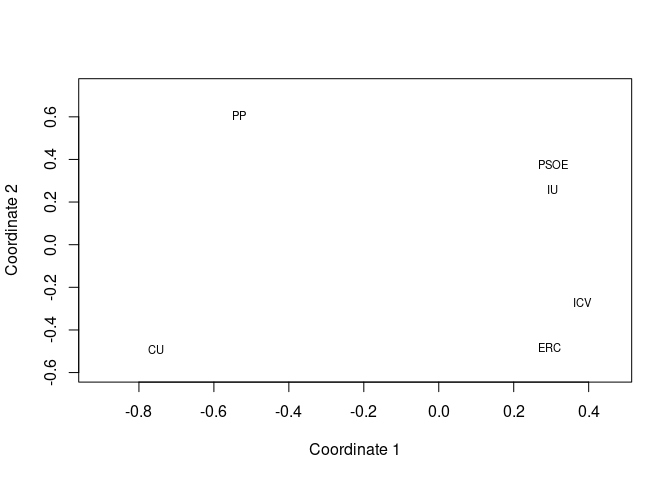

```r
xlim <- range(coords[,1] * (-1)) * 1.2
ylim <- range(coords[,2] * (-1)) * 1.2
plot(coords[,1] * (-1), coords[,2] * (-1),
     type = "n", xlab = "Coordinate 1", ylab = "Coordinate 2",
     xlim = xlim, ylim = ylim)
text(coords[,1] * (-1), coords[,2] * (-1),
     rownames(simPartidos), cex = 0.7)
```

# Análisis de correspondencias

- El análisis de correspondencias es una técnica que resulta especialmente adecuada para analizar y visualizar datos de tablas de contingencia con datos de frecuencias numéricas.
- Como en el caso del PCA y el MDS este análisis proporciona una representación de datos en dimensión reducida que facilita la interpretación y la comprensión de los datos.
- En este caso, además, es posible una representación simultánea muy intuitiva de los atributos de las filas y las columnas, lo que, en las circunstancias adecuadas, permite visualizar el grado de asociación entre unas y otras.

## Ejemplo 1: Representación de mutaciones cromosómicos entre poblaciones

Este primer ejemplo es un análisis clásico basado en estudios de genética de poblaciones de los años 70. En primer lugar se presenta la realización del análisis “empaquetado” para después ilustrarl su realización paso a paso.

*Alonso (1975)* hace un amplio estudio de la distribución geográfica del polimorfismo cromosómico de *Drosophila subobscura* utilizando análisis factorial de correspondencias.

```r
kableExtra::kable(datos)
```

|  | A-ST | A-1 | A-2 |
| --- | --- | --- | --- |
| HELSINKI | 96.0 | 4.0 | 0.0 |
| DROBACK | 78.4 | 16.2 | 5.4 |
| HARIOT | 100.0 | 0.0 | 0.0 |
| DALKEITH | 100.0 | 0.0 | 0.0 |
| GRONINGEN | 80.0 | 16.0 | 4.0 |
| FONTAINEBLEAU | 88.5 | 7.7 | 3.8 |
| VIENA | 56.9 | 35.8 | 7.4 |
| ZURICH | 67.8 | 24.4 | 7.8 |
| FRUSKA-GORA | 36.1 | 55.6 | 8.3 |
| LAGRASSE | 72.5 | 17.5 | 10.0 |
| MONTPELLIER | 60.2 | 24.3 | 15.5 |
| CARASCO | 50.0 | 31.8 | 18.2 |

Obsérvese como un gráfico sencillo puede dar buena idea de qué relaciones entre filas y columnas esperamos encontrar:

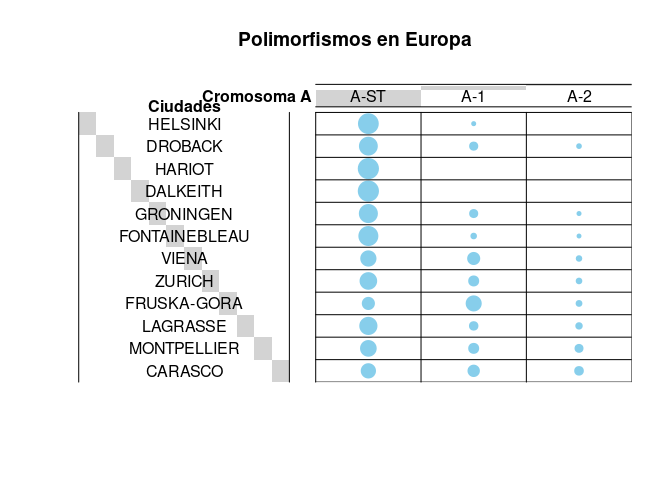

```r
library("gplots")
# 1. convert the data as a table
dt <- as.table(datos)
# 2. Graph
balloonplot(t(dt), main ="Polimorfismos en Europa", xlab ="Cromosoma A", ylab="Ciudades",
            label = FALSE, show.margins = FALSE)
```

Si realizamos el análisis usando la función `CA` del paquete `FactoMineR` obtenemos los siguientes resultados:

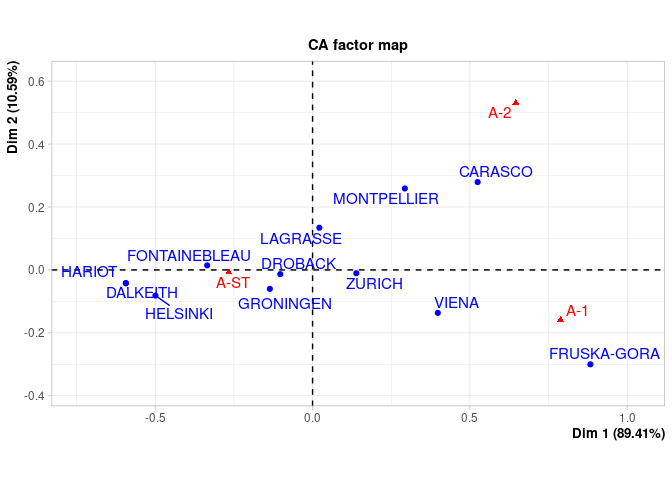

```r
library(FactoMineR)
datos.ca <- CA(datos, graph = FALSE)
plot.CA(datos.ca)
```

### Realización del análisis paso por paso

Aunque, en la práctica, solemos utilizar librerías de R que “empaquetan” en funciones propias las transformaciones y análisis de los datos, resulta instructivo realizar algún análisis paso a paso, ya sea para tener una mejor comprensión del análisis realizado o, incluso, para saber cuando puede ser preciso buscar alternativas porque se dan condiciones particulares.

En esta sección realizaremos paso a paso el análisis de los datos anteriores comparando los resultados que obtenemos con los proporcionados por el paquete utilizado.

Empezamos transformando los datos en frecuencias relativas y calculando las frecuencias relativas marginales.

```r
tabla.N <- datos
N <- sum(tabla.N)
```

El análisis de esta tabla de frecuencias mediante análisis de correspondencias puede plantearse de dos formas:

1- Como un escalado multidimensional de filas y de columnas con la distancia ji-cuadrado. 2- Como un análisis de componentes principales sobre la matriz Z estandarizada.

#### Como un escalado multidimensional

Calculamos las tablas de frecuencias relativas y marginales:

```r
tabla.F <-   tabla.N/N
margin.f <- margin.table(tabla.F,1)
margin.c <- margin.table(tabla.F,2)
show(round(addmargins(tabla.F),4))
```

```
##                 A-ST    A-1    A-2    Sum
## HELSINKI      0.0800 0.0033 0.0000 0.0833
## DROBACK       0.0653 0.0135 0.0045 0.0833
## HARIOT        0.0833 0.0000 0.0000 0.0833
## DALKEITH      0.0833 0.0000 0.0000 0.0833
## GRONINGEN     0.0667 0.0133 0.0033 0.0833
## FONTAINEBLEAU 0.0737 0.0064 0.0032 0.0833
## VIENA         0.0474 0.0298 0.0062 0.0834
## ZURICH        0.0565 0.0203 0.0065 0.0833
## FRUSKA-GORA   0.0301 0.0463 0.0069 0.0833
## LAGRASSE      0.0604 0.0146 0.0083 0.0833
## MONTPELLIER   0.0502 0.0202 0.0129 0.0833
## CARASCO       0.0417 0.0265 0.0152 0.0833
## Sum           0.7386 0.1944 0.0670 1.0000
```

La solución mediante escalado multidimensional pasa por calcular la matriz de distancias jui-cuadrado por filas y/o por columnas y, sobre esta matriz, realizamos un escalado multidimensional. Es decir realizamos dos cálculos separados que *podremos superponer después*

**Análisis de la tabla basado en los perfiles “fila”**

A partir de la tabla de frecuencias relativas podemos calcular la tabla de frecuencias relativas condicionada por filas (haciendo que éstas sumen 1).

```r
Y<- tabla.P <- diag(1/margin.f) %*% tabla.F
show(round(addmargins(Y),4))
```

```
##       A-ST    A-1    A-2 Sum
##     0.9600 0.0400 0.0000   1
##     0.7840 0.1620 0.0540   1
##     1.0000 0.0000 0.0000   1
##     1.0000 0.0000 0.0000   1
##     0.8000 0.1600 0.0400   1
##     0.8850 0.0770 0.0380   1
##     0.5684 0.3576 0.0739   1
##     0.6780 0.2440 0.0780   1
##     0.3610 0.5560 0.0830   1
##     0.7250 0.1750 0.1000   1
##     0.6020 0.2430 0.1550   1
##     0.5000 0.3180 0.1820   1
## Sum 8.8634 2.3326 0.8039  12
```

Calculamos la matriz de distancias ji cuadrado entre las filas. Obsérvese que para el cálculo de la distancia entre dos perfiles filas aplicamos la fórmula:

$$\begin{equation}
D^{2}\left(\mathbf{p}_{u}, \mathbf{p}_{v}\right)=\left(\mathbf{p}_{u}-\mathbf{p}_{v}\right)^{\prime} \mathbf{D}_{c}^{-1}\left(\mathbf{p}_{u}-\mathbf{p}_{v}\right)
\end{equation}$$

```r
nf <- nrow(tabla.F)
D2.chisq.f <- matrix(0,nf,nf)
for(i in 1:(nf-1))
  for(j in i:nf)
    D2.chisq.f[i,j] <-  t(Y[i,]-Y[j,]) %*% diag(1/margin.c) %*% (Y[i,]-Y[j,])
   D2.chisq.f <- D2.chisq.f + t(D2.chisq.f)
rownames(D2.chisq.f) <- colnames(D2.chisq.f) <- rownames(tabla.F)
show(round(D2.chisq.f,6))
```

```
##               HELSINKI  DROBACK   HARIOT DALKEITH GRONINGEN FONTAINEBLEAU
## HELSINKI      0.000000 0.162028 0.010397 0.010397  0.132616      0.036212
## DROBACK       0.162028 0.000000 0.241693 0.241693  0.003293      0.054798
## HARIOT        0.010397 0.241693 0.000000 0.000000  0.209726      0.069958
## DALKEITH      0.010397 0.241693 0.000000 0.000000  0.209726      0.069958
## GRONINGEN     0.132616 0.003293 0.209726 0.209726  0.000000      0.045279
## FONTAINEBLEAU 0.036212 0.054798 0.069958 0.069958  0.045279      0.000000
## VIENA         0.808178 0.265734 0.991703 0.991703  0.290720      0.560091
## ZURICH        0.412555 0.058399 0.537446 0.537446  0.078002      0.225358
## FRUSKA-GORA   1.958238 1.053343 2.245859 2.245859  1.095190      1.582225
## LAGRASSE      0.317785 0.037167 0.409191 0.409191  0.062509      0.141441
## MONTPELLIER   0.744114 0.230863 0.876825 0.876825  0.285920      0.454512
## CARASCO       1.178466 0.478943 1.353089 1.353089  0.551247      0.808971
##                  VIENA   ZURICH FRUSKA-GORA LAGRASSE MONTPELLIER  CARASCO
## HELSINKI      0.808178 0.412555    1.958238 0.317785    0.744114 1.178466
## DROBACK       0.265734 0.058399    1.053343 0.037167    0.230863 0.478943
## HARIOT        0.991703 0.537446    2.245859 0.409191    0.876825 1.353089
## DALKEITH      0.991703 0.537446    2.245859 0.409191    0.876825 1.353089
## GRONINGEN     0.290720 0.078002    1.095190 0.062509    0.285920 0.551247
## FONTAINEBLEAU 0.560091 0.225358    1.582225 0.141441    0.454512 0.808971
## VIENA         0.000000 0.082935    0.261880 0.214932    0.167245 0.188767
## ZURICH        0.082935 0.000000    0.637165 0.034706    0.096325 0.232512
## FRUSKA-GORA   0.261880 0.637165    0.000000 0.930412    0.659970 0.463832
## LAGRASSE      0.214932 0.034706    0.930412 0.000000    0.089422 0.274098
## MONTPELLIER   0.167245 0.096325    0.659970 0.089422    0.000000 0.053903
## CARASCO       0.188767 0.232512    0.463832 0.274098    0.053903 0.000000
```

Finalmente realizamos escalado multidimensional sobre la matriz de distancias *entre filas*.

```r
mds.f <- cmdscale(sqrt(D2.chisq.f),eig=TRUE)
mds.f
```

```
## $points
##                      [,1]        [,2]
## HELSINKI      -0.49930839 -0.08153341
## DROBACK       -0.10258763 -0.01341023
## HARIOT        -0.59336881 -0.04217206
## DALKEITH      -0.59336881 -0.04217206
## GRONINGEN     -0.13576678 -0.06022835
## FONTAINEBLEAU -0.33501017  0.01447700
## VIENA          0.39799723 -0.13649197
## ZURICH         0.13905244 -0.01046753
## FRUSKA-GORA    0.88289376 -0.30006242
## LAGRASSE       0.02154641  0.13409481
## MONTPELLIER    0.29331962  0.25884055
## CARASCO        0.52460114  0.27912567
##
## $eig
##  [1]  2.413616e+00  2.858896e-01  2.094107e-16  4.345524e-17  4.066088e-18
##  [6]  2.489385e-18 -2.535507e-17 -3.115774e-17 -3.458132e-17 -3.626690e-17
## [11] -3.969570e-17 -5.575297e-17
##
## $x
## NULL
##
## $ac
## [1] 0
##
## $GOF
## [1] 1 1
```

El resultado del MDS se puede representar para visualizar la relación entre las filas.

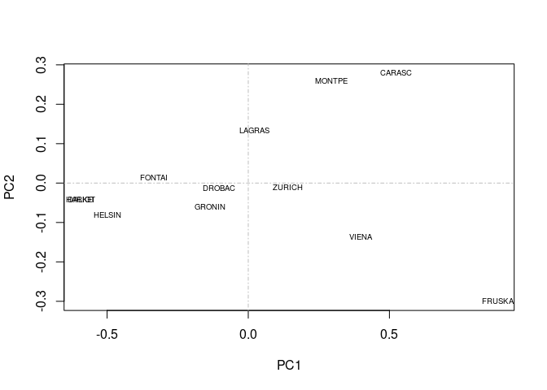

```r
plot(mds.f$points,ty="n",xlab="PC1",ylab="PC2")
abline(v=0,h=0, col="gray",lty=4)
text(mds.f$points[,1],mds.f$points[,2],labels=substr(rownames(tabla.N),1,6),cex=0.6)
```

**Análisis de la tabla basado en los perfiles “columna”**

```r
Y<- tabla.C <-   tabla.F %*% diag(1/margin.c)
show(round(addmargins(Y),4))
```

```
##                                       Sum
## HELSINKI      0.1083 0.0171 0.0000 0.1254
## DROBACK       0.0884 0.0694 0.0672 0.2251
## HARIOT        0.1128 0.0000 0.0000 0.1128
## DALKEITH      0.1128 0.0000 0.0000 0.1128
## GRONINGEN     0.0903 0.0686 0.0498 0.2086
## FONTAINEBLEAU 0.0998 0.0330 0.0473 0.1801
## VIENA         0.0642 0.1535 0.0920 0.3097
## ZURICH        0.0765 0.1046 0.0970 0.2781
## FRUSKA-GORA   0.0407 0.2383 0.1032 0.3823
## LAGRASSE      0.0818 0.0750 0.1244 0.2812
## MONTPELLIER   0.0679 0.1042 0.1928 0.3649
## CARASCO       0.0564 0.1363 0.2264 0.4191
## Sum           1.0000 1.0000 1.0000 3.0000
```

A continuación calculamos la matriz de distancias ji cuadrado entre las columnas.

```r
nc <- ncol(tabla.F)
D2.chisq.c <- matrix(0,nc,nc)
for(i in 1:(nc-1))
  for(j in i:nc)
    D2.chisq.c[i,j] <-  t(Y[,i]-Y[,j]) %*% diag(1/margin.f) %*% (Y[,i]-Y[,j])
   D2.chisq.c <- D2.chisq.c + t(D2.chisq.c)
rownames(D2.chisq.c) <- colnames(D2.chisq.c) <- colnames(tabla.F)
show(round(D2.chisq.c,6))
```

```
##          A-ST      A-1      A-2
## A-ST 0.000000 1.135265 1.121353
## A-1  1.135265 0.000000 0.496044
## A-2  1.121353 0.496044 0.000000
```

Finalmente realizamos escalado multidimensional sobre la matriz de distancias *entre columnas*.

```r
mds.c <- cmdscale(sqrt(D2.chisq.c),eig=TRUE)
mds.c
```

```
## $points
##            [,1]         [,2]
## A-ST  0.6680866 -0.003873443
## A-1  -0.3395554 -0.350171946
## A-2  -0.3285312  0.354045388
##
## $eig
## [1]  6.695703e-01  2.479835e-01 -3.330669e-16
##
## $x
## NULL
##
## $ac
## [1] 0
##
## $GOF
## [1] 1 1
```

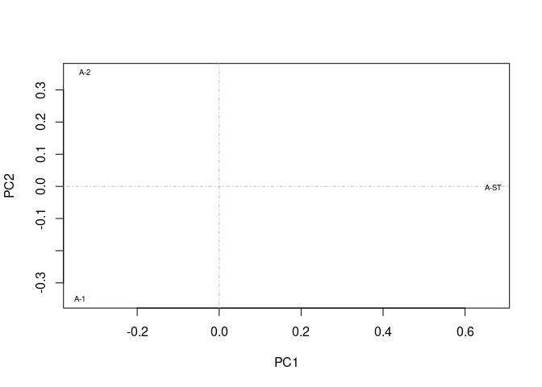

```r
plot(mds.c$points,ty="n",xlab="PC1",ylab="PC2")
abline(v=0,h=0, col="gray",lty=4)
text(mds.c$points[,1],mds.c$points[,2],labels=substr(colnames(tabla.F),1,6),cex=0.6)
```

Finalmente observemos que podemos superponer los dos gráficos:

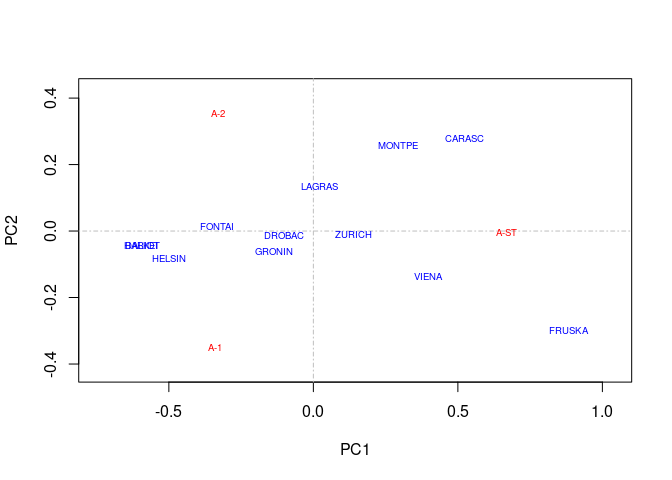

```r
xinf<- min(min(mds.c$points[,1]), min(mds.f$points[,1]))
xsup <- max(max(mds.c$points[,1]), max(mds.f$points[,1]))
yinf<- min(min(mds.c$points[,2]), min(mds.f$points[,2]))
ysup <- max(max(mds.c$points[,2]), max(mds.f$points[,2]))
xdelta<- (xsup-xinf)/10
ydelta<- (ysup-yinf)/10
xLim <- c(xinf-xdelta, xsup+xdelta)
yLim <- c(yinf-ydelta, ysup+ydelta)

plot(mds.c$points,ty="n",xlab="PC1",ylab="PC2", xlim=xLim, ylim=yLim)
abline(v=0,h=0, col="gray",lty=4)
text(mds.f$points[,1],mds.f$points[,2],labels=substr(rownames(tabla.F),1,6),cex=0.6, col="blue")
text(mds.c$points[,1],mds.c$points[,2],labels=substr(colnames(tabla.F),1,6),cex=0.6, col="red")
```

#### AC como un ACP sobre la matriz estandarizada

El análisis se realiza sobre la matriz $\mathbf{Z}$:

$$\begin{equation}
\mathbf{Z}=\mathbf{D}_{f}^{1 / 2} \mathbf{Y}=\mathbf{D}_{f}^{-1 / 2} \mathbf{F} \mathbf{D}_{c}^{-1 / 2}=\left(\frac{f_{i j}}{\sqrt{f_{i} f_{\cdot j}}}\right)
\end{equation}$$

Sin embargo y para evitar que tengamos un valor propio 1, inútil ya que es una solución trivial, es mejor estandarizar la matriz de correspondencias y utilizar la matriz

$$\begin{equation}
\mathbf{Z}=\mathbf{D}_{f}^{-1 / 2}\left(\mathbf{F}-\mathbf{f} \mathbf{c}^{\prime}\right) \mathbf{D}_{c}^{-1 / 2}
\end{equation}$$

```r
Dfmh <- diag(1/sqrt(margin.f))
Dcmh <- diag(1/sqrt(margin.c))
Z <-  Dfmh %*% (tabla.F -margin.f%*% t(margin.c)) %*% Dcmh
rownames(Z) <- rownames(tabla.F)
colnames(Z) <- colnames(tabla.F)
round(Z,4)
```

```
##                  A-ST     A-1     A-2
## HELSINKI       0.0744 -0.1011 -0.0747
## DROBACK        0.0152 -0.0212 -0.0145
## HARIOT         0.0878 -0.1273 -0.0747
## DALKEITH       0.0878 -0.1273 -0.0747
## GRONINGEN      0.0206 -0.0225 -0.0301
## FONTAINEBLEAU  0.0492 -0.0769 -0.0323
## VIENA         -0.0572  0.1069  0.0077
## ZURICH        -0.0204  0.0325  0.0123
## FRUSKA-GORA   -0.1268  0.2367  0.0179
## LAGRASSE      -0.0046 -0.0127  0.0368
## MONTPELLIER   -0.0459  0.0318  0.0981
## CARASCO       -0.0801  0.0809  0.1283
```

Realizaremos el ACP mediante la descomposición en valores singulares de Z:

```r
Z.svd <- svd(Z)
Z.svd
```

```
## $d
## [1] 4.484765e-01 1.543493e-01 9.873327e-17
##
## $u
##              [,1]        [,2]        [,3]
##  [1,] -0.32140123  0.15248587  0.07381359
##  [2,] -0.06605194  0.02506336 -0.63211506
##  [3,] -0.38194412  0.07887700 -0.36427518
##  [4,] -0.38194412  0.07887700 -0.36427518
##  [5,] -0.08740702  0.11262391 -0.10796048
##  [6,] -0.21565180 -0.02708007  0.12192167
##  [7,]  0.25628095  0.25535378 -0.08549819
##  [8,]  0.08948031  0.01954840 -0.32704646
##  [9,]  0.56826058  0.56111153 -0.21012822
## [10,]  0.01384486 -0.25080562 -0.22780512
## [11,]  0.18877038 -0.48411733 -0.01597526
## [12,]  0.33763503 -0.52206548 -0.30413048
##
## $v
##            [,1]        [,2]      [,3]
## [1,] -0.5099814  0.03624682 0.8594214
## [2,]  0.7751769  0.45243825 0.4409087
## [3,]  0.3728536 -0.89105881 0.2588328
```

De aquí se obtienen las coordenadas principales y estándar:

```r
f.sc <- diag(1/sqrt(margin.f)) %*% Z.svd$u
c.sc <- diag(1/sqrt(margin.c)) %*% Z.svd$v
f.pc <- f.sc %*% diag(Z.svd$d)
c.pc <- c.sc %*% diag(Z.svd$d)
```

Podemos finalmente representar las distancias con filas y columnas de **Z**

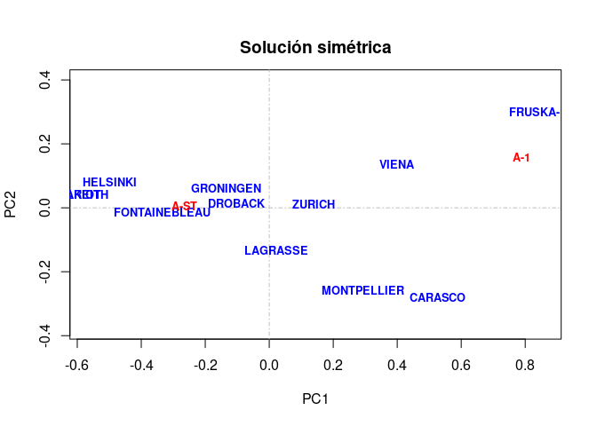

```r
library(MASS)
# solución simétrica
eqscplot(f.pc[,1:2],type="n",xlab="PC1",ylab="PC2")
abline(v=0,h=0, col="gray",lty=4)
text(f.pc[,1],f.pc[,2],labels=rownames(tabla.F),cex=0.8,font=2,col="blue")
text(c.pc[,1],c.pc[,2],labels=colnames(tabla.F),cex=0.8,font=2,col= "red")
title(main="Solución simétrica",line=1)
```

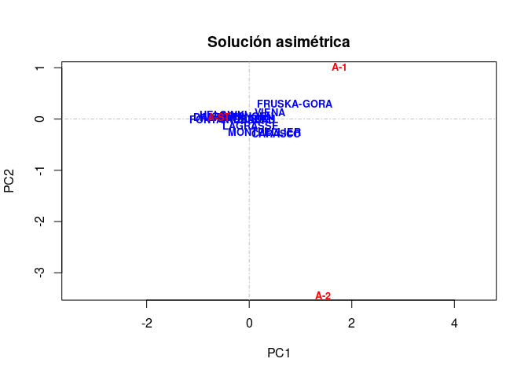

```r
#
# solución asimétrica
eqscplot(c.sc[,1:2],type="n",xlab="PC1",ylab="PC2")
abline(v=0,h=0, col="gray",lty=4)
text(f.pc[,1],f.pc[,2],labels=rownames(tabla.F),cex=0.8,font=2,col="blue")
text(c.sc[,1],c.sc[,2],labels=colnames(tabla.F),cex=0.8,font=2,col= "red")
title(main="Solución asimétrica",line=1)
```

## Ejemplo 2: Análisis de correspondencias de datos de microarrays

El AC se presenta tradicionalmente como una técnica para el análisis de tablas de frecuencias, pero estríctamente hablando, si podemos expresar unos datos cuantitativos como perfiles fila y perfiles columna, tambien se puede aplicar a otros tipos de datos.

Un ejemplo de esto fue la aplicación a principios de este siglo a datos de microarrays por Fellenberg K (2001). El interes de esta aplicación reside sobretodo en la posibilidad de visualizar simultaneamente expresión de genes e individuos/condiciones experimentales.

El ejemplo se lleva a cabo usando el paquete de R/Bioconductor `made4` que es una extensión, para ser usada en datos ómicos, del paquete `ade4`, un programa muy popular en francia para el análisis exploratorio de datos.

El paquete `made4` (Culhane AC (2005)) contiene algunos *datasets* de ejemplo. Usaremos el subconjunto de datos `data.train` del dataset `khan`. La función `overview` permite una rápida visualización de un dataset dado.

```r
library(made4)
data("khan")
names(khan)
```

```
## [1] "train"                "test"                 "train.classes"
## [4] "test.classes"         "annotation"           "gene.labels.imagesID"
## [7] "cellType"
```

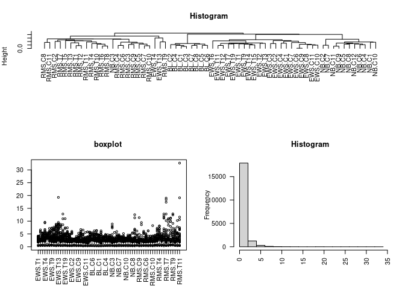

```r
k.data<-khan$train
k.class<-khan$train.classes
overview(k.data)
```

EL paquete contiene la función `ord` que permite realizar distintos métodos de reducción de la dimensión cambiando un argumento. Para análisis de correspondencias es `coa`. Para saber más puede hacerse `help (ord)`.

```r
k.coa<- ord(k.data, type="coa")
show(k.coa)
```

```
## $ord
## Duality diagramm
## class: coa dudi
## $call: dudi.coa(df = data.tr, scannf = FALSE, nf = ord.nf)
##
## $nf: 63 axis-components saved
## $rank: 63
## eigen values: 0.1713 0.1383 0.1032 0.05995 0.04965 ...
##   vector length mode    content
## 1 $cw    64     numeric column weights
## 2 $lw    306    numeric row weights
## 3 $eig   63     numeric eigen values
##
##   data.frame nrow ncol content
## 1 $tab       306  64   modified array
## 2 $li        306  63   row coordinates
## 3 $l1        306  63   row normed scores
## 4 $co        64   63   column coordinates
## 5 $c1        64   63   column normed scores
## other elements: N
##
## $fac
## NULL
##
## attr(,"class")
## [1] "coa" "ord"
```

La forma más sencilla de ver los resultados producidos por `ord` es utilizar `plot`. `plot (k.ord)` dibujará un gráfico de los valores propios, junto con los gráficos de las variables (genes) y un gráfico de los casos (muestras de microarrays). En este ejemplo, las muestras de microarrays están codificadas por colores utilizando la variable `k.classes` que se guarda como `k.class`.

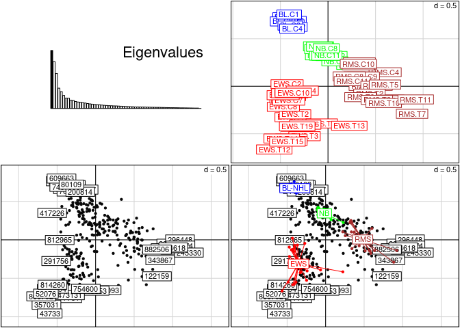

```r
plot(k.coa, classvec=k.class, genecol="grey3")
```

- La imagen muestra arriba a la izquierda (A) el gráfico de los valores propios, lo que permite hacerse una idea de cuantas dimensiones retener.
- Arriba a la derecha (B) se muestra la proyección de las muestras de microarrays de pacientes coloreadas por tipos de tumores EWS (rojo), BL (azul), NB (verde) o RMS (marrón)
- Abajo a la izquierda (C) se muestra la proyección de los genes (círculos grises rellenos).
- Finalmente, abajo a la derecha (D) se muestra el biplot con los genes superpuestos con la muestras.

Las muestras y genes con una fuerte asociado se proyectan en la misma dirección desde el origen. Cuanto mayor sea la distancia desde el origen, más fuerte será la asociación.

# Análisis de conglomerados (“Cluster Analysis”)

El análisis de conglomerados pertenece al conjunto de técnicas conocidas com “análisis no supervisado” porque su objetivo es descubrir grupos en los datos, es decir grupos de individuos (o eventualmente de variables) que pueden considerarse más similares entre ellos que a los individuos de los otros grupos, según el criterio de similaridad que se decida utilizar.

Presentaremos dos ejemplos distintos:

## Agrupación de genes y de muestras en el análisis del ciclo celular

## Clustering y visualización

En este caso se presentan distintos métodos de agrupación ("clustering") disponibles en R y Bioconductor. Se utilizará el conjunto de datos `yeast` que puede descargarse desde la página del proyecto "Yeast Cell Cycle Project" (Proyecto de estudio del ciclo celular de la levadura) en la dirección:  
http://genome-www.stanford.edu/cellcycle/data/rawdata/.

Para descargarlo se tiene que acceder a la dirección mencionada y, desde ella, seleccionar el enlace "Tab delimited data" y descargar el archivo `combined.txt`.

### Pre-procesamiento de los datos

La agrupación de datos se suele aplicar después del pre-procesamiento y filtrado de los mismos. El conjunto de datos de ejemplo ya ha sido normalizado y filtrado por lo que no nos ocuparemos de este aspecto.

El archivo de datos contiene información de varios experimentos (`factor alfa, cdc15 y cinéticas de decantación`). Para simplificar en este ejercicio nos ocuparemos únicamente de los datos denominados "cdc15" ("cell division control protein 15").

EL primer paso consiste en extraer los valores del grupo `cdc15` del conjunto de datos pre-normalizados y eliminar los genes con valores faltantes:

```r
workingDir <- getwd()
dataDir <- file.path(workingDir, "datos")
d <- read.table(file.path(dataDir, "combined.txt"), sep="\t", header=T)
names(d)
```

```
##  [1] "X"         "cln3.1"    "cln3.2"    "clb"       "clb2.2"    "clb2.1"
##  [7] "alpha"     "alpha0"    "alpha7"    "alpha14"   "alpha21"   "alpha28"
## [13] "alpha35"   "alpha42"   "alpha49"   "alpha56"   "alpha63"   "alpha70"
## [19] "alpha77"   "alpha84"   "alpha91"   "alpha98"   "alpha105"  "alpha112"
## [25] "alpha119"  "cdc15"     "cdc15_10"  "cdc15_30"  "cdc15_50"  "cdc15_70"
## [31] "cdc15_80"  "cdc15_90"  "cdc15_100" "cdc15_110" "cdc15_120" "cdc15_130"
## [37] "cdc15_140" "cdc15_150" "cdc15_160" "cdc15_170" "cdc15_180" "cdc15_190"
## [43] "cdc15_200" "cdc15_210" "cdc15_220" "cdc15_230" "cdc15_240" "cdc15_250"
## [49] "cdc15_270" "cdc15_290" "cdc28"     "cdc28_0"   "cdc28_10"  "cdc28_20"
## [55] "cdc28_30"  "cdc28_40"  "cdc28_50"  "cdc28_60"  "cdc28_70"  "cdc28_80"
## [61] "cdc28_90"  "cdc28_100" "cdc28_110" "cdc28_120" "cdc28_130" "cdc28_140"
## [67] "cdc28_150" "cdc28_160" "elu"       "elu0"      "elu30"     "elu60"
## [73] "elu90"     "elu120"    "elu150"    "elu180"    "elu210"    "elu240"
## [79] "elu270"    "elu300"    "elu330"    "elu360"    "elu390"
```

```r
cdc15 <- which(substr(names(d),1,6)=="cdc15_")
dat <- d[,cdc15]
names(dat)
```

```
##  [1] "cdc15_10"  "cdc15_30"  "cdc15_50"  "cdc15_70"  "cdc15_80"  "cdc15_90"
##  [7] "cdc15_100" "cdc15_110" "cdc15_120" "cdc15_130" "cdc15_140" "cdc15_150"
## [13] "cdc15_160" "cdc15_170" "cdc15_180" "cdc15_190" "cdc15_200" "cdc15_210"
## [19] "cdc15_220" "cdc15_230" "cdc15_240" "cdc15_250" "cdc15_270" "cdc15_290"
```

```r
rownames(dat) <- d$X
dat <- na.omit(dat)
colnames(dat)
```

```
##  [1] "cdc15_10"  "cdc15_30"  "cdc15_50"  "cdc15_70"  "cdc15_80"  "cdc15_90"
##  [7] "cdc15_100" "cdc15_110" "cdc15_120" "cdc15_130" "cdc15_140" "cdc15_150"
## [13] "cdc15_160" "cdc15_170" "cdc15_180" "cdc15_190" "cdc15_200" "cdc15_210"
## [19] "cdc15_220" "cdc15_230" "cdc15_240" "cdc15_250" "cdc15_270" "cdc15_290"
```

Los datos descargados de la web habían sido previamente normalizados. Para comprobarlo podemos realizar un boxplot y comprobar que los datos presentan una distribución similar y centrada en el cero como sería de esperar con valores de expresión relativa normalizados.

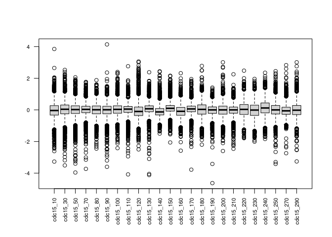

```r
boxplot(dat, las=2, cex.axis=0.7)
```

```r
percentage <- c(0.975)
sds <- apply(dat, MARGIN=1, FUN="sd")
sel <- (sds>quantile(sds,percentage))
dat.sel <- dat[sel, ]
dim(dat.sel)
```

```
## [1] 110  24
```

### Agrupación jerárquica de las muestras

La primera aproximación que suele hacerse para establecer la relación entre entre muestras es la aplicación de algun método de agrupamiento jerárquico. En este caso se realizará un cluster jerárquico basado en distancias euclídeas y enlaces promedio ("average linkage’’).

```r
distmeth <- c("euclidian")
Distan <- dist(t(dat.sel), method=distmeth)
treemeth <- c("average")
hc <- hclust(Distan, method=treemeth)
```

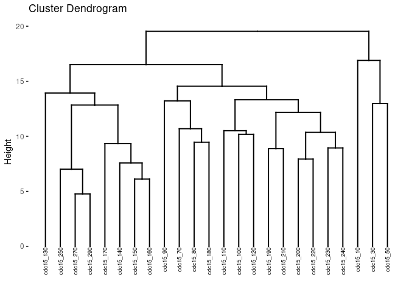

Esta no es la única forma de realizar este tipo de agrupación y , en general se recomienda probar con distintos métodos "razonables" y ver hasta que punto cambian los resultados que se obtiene.

### Ejercicio

Dibujar un dendrograma utilizando el método de distancias mínimas ("single linkage") y el de distancias máximas ("complete linkage").

A pesar que en los ejemplos anteriores se han utilizado distancias euclídeas, los perfiles de expresión génica acostumbran a agruparse en función de los coeficientes de correlación.

Para ello es necesario calcular la correlación entre los genes y cambiar el formato de la matriz de correlación para pueda contener las distancias. A continuación, el árbol puede dibujarse normalmente.

```r
cor.pe <- cor(as.matrix(dat.sel), method=c("pearson"))
cor.pe.rows <- cor(t(as.matrix(dat.sel)), method=c("pearson"))
cor.sp <- cor(as.matrix(dat.sel), method=c("spearman"))
dist.pe <- as.dist(1-cor.pe)
dist.pe.rows <- as.dist(1-cor.pe.rows)
dist.sp <- as.dist(1-cor.sp)
hc.cor <- hclust(dist.pe, method=treemeth)
hc.cor.rows <- hclust(dist.pe.rows, method=treemeth)
```

[figure not shown]

Repetir el ejercicio anterior cambiando el coeficiente de Pearson por el de Spearman. ?Los resultados son diferentes?

### Agrupación de genes por el método de las `k-means`

Si en lugar de muestras deseamos agrupar por genes es mejor usar métodos no jerárquicos partitivos como `k-means`.

Un inconveniente de l’agrupación por `k-means` es que hace falta escoger un número el número de clusters ($k$) antes de realizar la agrupación.

Por ejemplo para producir un agrupamiento k-means con 5 grupos haremos:

```r
k <- c(5)
km <- kmeans(dat.sel, k, iter.max=1000)
```

El método de las `k-means` permite estudiar la consistencia de la agrupación a partir del cálculo de las sumas de cuadrados dentro de cada grupo (*Within SS*). El promedio de estas sumas de cuadrados para todos los grupos creados (variable "withinss") es una medida de la variabilidad dentro de los grupos, es decir qué tan parecidos son los genes dentro de los grupos.

```r
mean(km$withinss)
```

[output not shown]

Una manera de evaluar las agrupaciones generadas mediante "k-means" es ejecutar el mismo análisis varias veces – guardando cada vez el resultado como un nuevo objeto – y seleccionar aquella agrupación que ofrece un menor valor de "withinss".

#### Dibujo de una agrupación `k-means`

Los resultados de los métodos divisivos como k-means`k-means` no pueden visualizarse mediante un dendrograma por lo que es preciso recurrir a otras representaciones gráficas.

Podemos, por ejemplo, pintar los miembros de cada grupo con un color y un símbolo distintos.

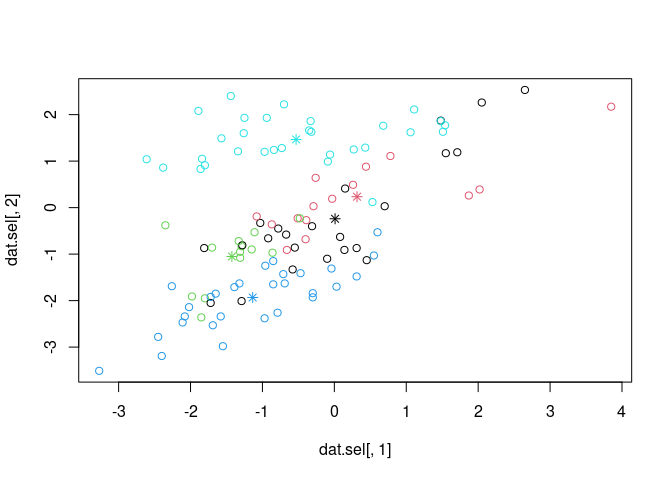

Para visualizar un sólo grupo, y sus valores de expresión, seleccionaremos los genes que lo constituyen y a continuación, dibujaremos los perfiles de expresión de estos genes utilizando diferentes colores.

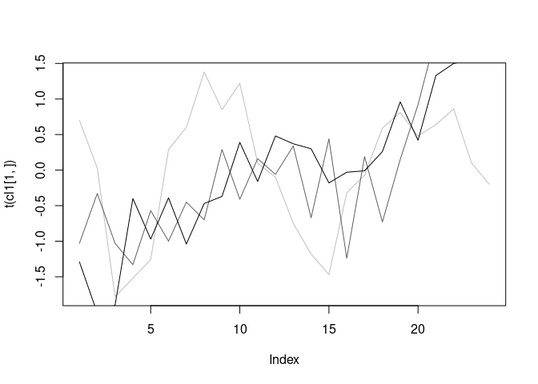

Si hay más de un grupo podemos visualizarlos todos en el mismo gráfico utilizando un peque~no bucle `for`

```r
km <- kmeans(dat.sel, 4, iter.max=1000)
```

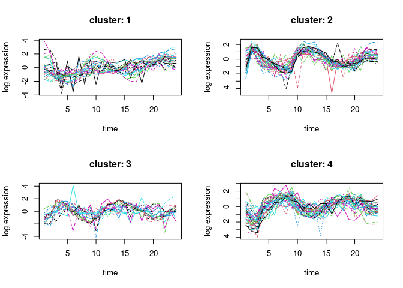

### Anotación de resultados

Una vez que se han identificado algunos grupos de interés, se puede comprobar que genes constituyen de cada uno de los "clusters". Esto puede hacerse con el paquete de anotaciones para levadura de donde podremos extraer información sobre nombres, descripciones y otras anotaciones en múltiples bases de datos:

```r
if(!require(org.Sc.sgd.db)){
 BiocManager::install("org.Sc.sgd.db")
}
require("org.Sc.sgd.db")
anotData <- capture.output(org.Sc.sgd())
print(anotData[1:15])
```

```
##  [1] "Quality control information for org.Sc.sgd:"
##  [2] ""
##  [3] ""
##  [4] "This package has the following mappings:"
##  [5] ""
##  [6] "org.Sc.sgdALIAS has 4468 mapped keys (of 8061 keys)"
##  [7] "org.Sc.sgdCHR has 8061 mapped keys (of 8061 keys)"
##  [8] "org.Sc.sgdCHRLENGTHS has 17 mapped keys (of 17 keys)"
##  [9] "org.Sc.sgdCHRLOC has 7993 mapped keys (of 8061 keys)"
## [10] "org.Sc.sgdCHRLOCEND has 7993 mapped keys (of 8061 keys)"
## [11] "org.Sc.sgdCOMMON2ORF has 12361 mapped keys (of 12361 keys)"
## [12] "org.Sc.sgdDESCRIPTION has 8052 mapped keys (of 8061 keys)"
## [13] "org.Sc.sgdENSEMBL has 5798 mapped keys (of 8061 keys)"
## [14] "org.Sc.sgdENSEMBL2ORF has 5804 mapped keys (of 5804 keys)"
## [15] "org.Sc.sgdENSEMBLPROT has 5798 mapped keys (of 8061 keys)"
```

```r
cat ("... output continues until ", length(anotData), " lines.\n")
```

```
## ... output continues until  46  lines.
```

Podemos utilizar las funciones de anotacion para convertir los identificadores propios a identificadores más generals (“Entrezs”) enriqueciéndolos con información sobre dichos genes.

```r
genes<-rownames(dat.sel)
columns(org.Sc.sgd.db)
```

```
##  [1] "ALIAS"        "COMMON"       "DESCRIPTION"  "ENSEMBL"      "ENSEMBLPROT"
##  [6] "ENSEMBLTRANS" "ENTREZID"     "ENZYME"       "EVIDENCE"     "EVIDENCEALL"
## [11] "GENENAME"     "GO"           "GOALL"        "INTERPRO"     "ONTOLOGY"
## [16] "ONTOLOGYALL"  "ORF"          "PATH"         "PFAM"         "PMID"
## [21] "REFSEQ"       "SGD"          "SMART"        "UNIPROT"
```

```r
geneAnots <-select(org.Sc.sgd.db, genes,c("SGD", "ENTREZID", "GENENAME"))
head(geneAnots)
```

```
##       ORF        SGD ENTREZID GENENAME
## 1 YAR007C S000000065   851266     RFA1
## 2 YBL003C S000000099   852283     HTA2
## 3 YBL051C S000000147   852229     PIN4
## 4 YBR038W S000000242   852326     CHS2
## 5 YBR054W S000000258   852343     YRO2
## 6 YBR092C S000000296   852389     PHO3
```

```r
###################################################
### code chunk number 15: genesInClusters
###################################################
genesInClusters <- cbind(geneAnots, cl)
kableExtra::kable(genesInClusters[order(genesInClusters$cl),])
```

|  | ORF | SGD | ENTREZID | GENENAME | cl |
| --- | --- | --- | --- | --- | --- |
| YBR202W | YBR202W | S000000406 | 852501 | MCM7 | 1 |
| YCL027W | YCL027W | S000000532 | 850330 | FUS1 | 1 |
| YCL040W | YCL040W | S000000545 | 850317 | GLK1 | 1 |
| YCL055W | YCL055W | S000000560 | 850303 | KAR4 | 1 |
| YCR098C | YCR098C | S000000695 | 850462 | GIT1 | 1 |
| YER103W | YER103W | S000000905 | 856840 | SSA4 | 1 |
| YGL055W | YGL055W | S000003023 | 852825 | OLE1 | 1 |
| YGL089C | YGL089C | S000003057 | 852791 | MF(ALPHA)2 | 1 |
| YJL159W | YJL159W | S000003695 | 853281 | HSP150 | 1 |
| YJR004C | YJR004C | S000003764 | 853460 | SAG1 | 1 |
| YKL163W | YKL163W | S000001646 | 853693 | PIR3 | 1 |
| YKL164C | YKL164C | S000001647 | 853692 | PIR1 | 1 |
| YKL177W | YKL177W | S000001660 | NA | NA | 1 |
| YKL178C | YKL178C | S000001661 | 853677 | STE3 | 1 |
| YKL185W | YKL185W | S000001668 | 853650 | ASH1 | 1 |
| YLL024C | YLL024C | S000003947 | 850636 | SSA2 | 1 |
| YLL026W | YLL026W | S000003949 | 850633 | HSP104 | 1 |
| YLR247C | YLR247C | S000004237 | 850949 | IRC20 | 1 |
| YMR186W | YMR186W | S000004798 | 855224 | HSC82 | 1 |
| YNL007C | YNL007C | S000004952 | 855725 | SIS1 | 1 |
| YNL057W | YNL057W | S000005002 | NA | NA | 1 |
| YNR044W | YNR044W | S000005327 | 855780 | AGA1 | 1 |
| YPR158W | YPR158W | S000006362 | 856281 | CUR1 | 1 |
| YBL051C | YBL051C | S000000147 | 852229 | PIN4 | 2 |
| YBR110W | YBR110W | S000000314 | 852407 | ALG1 | 2 |
| YBR138C | YBR138C | S000000342 | 852435 | NA | 2 |
| YDL037C | YDL037C | S000002195 | 851524 | BSC1 | 2 |
| YDL039C | YDL039C | S000002197 | 851522 | PRM7 | 2 |
| YDL077C | YDL077C | S000002235 | 851482 | VAM6 | 2 |
| YDL234C | YDL234C | S000002393 | 851364 | GYP7 | 2 |

[output cut: 80 more lines]

## Algunas fuentes con ejemplos adicionales sobre análisis de conglomerados:

[Ejemplos de cluster analysis con R del profesor Gabriel Martos](https://rpubs.com/gabrielmartos/ClusterAnalysis) [El paquete cluster.datasets, con los datasets de un clásico sobre análisisd e conglomerados (Hartigan)](https://cran.r-project.org/web/packages/cluster.datasets/cluster.datasets.pdf) [Materiales de Thomas Girke, bioinformatico de la UCR, sobre Clustering](http://girke.bioinformatics.ucr.edu/GEN242/pages/mydoc/Rclustering.html)

# Referencias

Alonso, G. 1975. “Estudio de La Distribución Geográfica Del Polimorfismo Cromosómico En Drosophila Suboscura.” *Facultat Biologia*.

Cuadras, C. M. 2007. “Exemples d’Anàlisi Multivariant.”

———. 2019. “Nuevos Métodos de Análisis Multivariante.”

Culhane AC, Perriere G, Thioulouse J. 2005. “ADE4: An R Package for Multivariate Analysis of Gene Expression Data.” *Bioinformatics* 21(11): 2789–90.

Everitt, Brian, and Torsten Hothorn. 2011. *An Introduction to Applied Multivariate Analysis with R*. New York: Springer. http://dx.doi.org/10.1007/978-1-4419-9650-3.

Fellenberg K, Brors B, Hauser NC. 2001. “Correspondence Analysis Applied to Microarray Data.” *Proc Natl Acad Sci U S A* 98(19): 10781–6.

[^1]: El ejemplo de los gorriones se ha tomado del documento *Exemples d’Anàlisi Multivariant* del Dr. Carles Cuadras disponible en su página web.
[^2]: El ejemplo de la visualización de distancias entre ciudades se ha tomado del libro de Everitt and Hothorn (2011) *An introduction to aplied multivariate analysis using R* y del repositorio de github en donde se encuentra el código R de dicho libro: https://rdrr.io/cran/MVA/
[^3]: El ejemplo de la relación entre partidos políticos se ha tomado del documento Cuadras (2007), *Exemples d’Anàlisi Multivariant* del Dr. Carles Cuadras disponible en su página web.